DS 3001 - 001

# Foundations of Machine Learning

[figure not shown]

## Welcome to DS 3001

Today:

- teaching team;
- what you will learn and how class works;
- coursework and grading; and
- one live practice run through the assignment workflow.

Stop me with questions as we go.

## Instructor

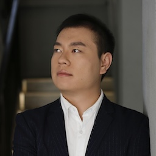

**Lei Li**  
Assistant Professor, School of Data Science

leili@virginia.edu

**Office**: 2125 Ivy Road, Charlottesville

**Office hours**: September 1–December 8,

- Tuesday, 10:30 a.m.–12:00 p.m.
- Tuesday, 3:30–5:00 p.m.

## Instructional Support

**Samia Mahmood**

ncq3dw@virginia.edu

**Office location and hours**: to be announced in Canvas

Your section TA helps in studio, grades coursework, answers questions, and handles grace-day requests.

## Python + Technical Support Hours

[figure not shown]

[Python Support Hours on GitHub](https://github.com/ali-rivera/Python-Support-Hours)

## How to Reach Us

- **Canvas Discussions**: course questions, so your classmates can find the answer too.
- **Email**: personal, private, or accommodation questions.

We answer as soon as we can on working days.

The official announcements, deadlines, assignment links, and grades live in Canvas.

## Data Science

**Data science** is the study of data and the methods used to learn from data.

A question becomes an answer only after someone prepares the data, picks a method, checks the result, and explains what it shows.

That whole path is the work of this course.

## Data Science Is More Than One Skill

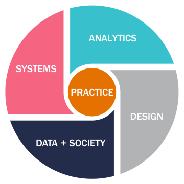

The 4 + 1 Model

Analytics, systems, design, and data and society all meet in practice.

We work from the analytics side and keep asking what a result means for the people in the data.

## Machine Learning

**Machine learning** uses data and algorithms to build models that describe patterns and make predictions.

- Data science is the wider practice: the question, the data, the method, the check, and the explanation.
- Machine learning is the modeling step inside that practice.

## Every Analysis Starts With a Question

1. Ask a question the data can answer.
2. Prepare and explore the data.
3. Choose a method that fits.
4. Check the result.
5. Analyze what it shows or does not show.

Every step points back to step 1.

State limitations plainly: a result should not claim more than the question and data support.

## What You Will Learn

By the end of the semester you will be able to:

- prepare, summarize, and visualize data;
- choose and implement methods that fit the question;
- design comparisons, checks, and evaluation measures;
- interpret results, uncertainty, and limitations;
- build reproducible work with Python, Jupyter, Git, and GitHub; and
- evaluate AI assistance and stay responsible for what you submit.

## The Road Through the Semester

1. **Work with data:** wrangling, exploratory analysis, and visualization.
2. **Core models:** k-nearest neighbors, clustering, linear models, decision trees, and principal component analysis.
3. **Advanced topics:** probability, the bootstrap, ensembles and random forests, cross-validation, regularization, logistic regression, and neural networks.

## When and Where We Meet

- **Monday and Wednesday, 2:00–3:15 p.m.**
- **Data Science Building, Room 305**
- In person, August 25 through December 8, 2026
- No class October 5 (Fall Reading Days) or November 25 (Thanksgiving recess)

We meet on Labor Day, Monday, September 7.

## Lecture Days and Studio Days

- In a **lecture**, we work through the concepts, the intuition, the mathematics, and examples.
- In a **studio**, you spend most of class on one assignment, lab, or project task while the teaching team circulates and helps.

The schedule in the syllabus names the mode for every meeting.

For studio, work on Jupyter notebooks and come with a specific question. Phase 1 checkpoints of assignments and labs happen there.

## The First Two Weeks

| Date | Meeting |
| --- | --- |
| Aug. 31 | Lecture: Data Wrangling |
| Sept. 2 | Studio: A1 Data Wrangling |
| Sept. 7 | Lecture: EDA and Visualization |
| Sept. 9 | Studio: A2 EDA and Visualization |

A1 is released August 31, checkpointed in studio on September 2, and submitted by September 6.

## What is the Coursework

- Five individual assignments.
- Three team labs.
- One semester project.
- No final exam.

## How the Grade Works

- **Assignments:** 30%
  - five at 6% each (individual work).
- **Labs:** 30%
  - three at 10% each (team work).
- **Semester project:** 40%
  - pitch 5%, final presentation 10%, report and technical materials 25% (team work).

## Team Work Has an Individual Part

The TA assigns initial teams in Canvas. You may request a change; rosters settle after the add/drop period.

For every lab and every graded project item:

- **80%** comes from the shared team work;
- **20%** comes from your own contribution.

You complete a peer and self evaluation after each lab, the pitch, the final presentation, and the report. A missing or late evaluation earns zero for that item’s individual portion.

Evaluations are confidential. Normal participation earns full credit.

## The Semester Project

- Teams of three students.
- Your own question, with data you obtain or assemble yourselves.
- Not Kaggle, the UCI repository, or other ready-made practice data.
- Pitch the question and data, build the analysis, present the result, and submit the final report.
- Before the pitch, check data access, licensing, privacy, and feasibility.

Fork the project template repository and build everything in your fork.

## Project Examples from the Past

- **Predicting NBA player salaries**
  - Question: Which 2024-25 on-court performance metrics best predict NBA players’ 2025-26 base salaries?
  - Data: Basketball-Reference player statistics for 2024-25 and base salaries for 2025-26.
  - Analysis: The team compared ordinary least squares (OLS), ridge regression for correlated predictors, lasso for feature selection, and random forest for nonlinear patterns, using five-fold cross-validation and held-out testing.

More in the syllabus.

Check the project selection policy and develop your own projects!

## Every Assignment and Lab Has Two Phases

**Phase 1 — 90%**

Do the notebook without generative AI. Commit, push, and record the commit ID.

**Phase 2 — 10%**

Use AI only to audit and revise that notebook. Record what it suggested, what you changed, and how you checked. Commit and push again.

Submit the repository URL and both commit IDs in Canvas.

Assignments use one fork per student. Labs use one shared fork per team and one group submission.

## AI Policy for Assignments and Labs

**Phase 1 — no generative AI**

- Including AI code completion and AI-written answers inside search results.
- Course notes, official documentation, ordinary web search, help from us, and concept discussion with classmates are fine.

**Phase 2 — AI assistance**

- Limited to auditing and revising your finished notebook.
- A documented correction restores at most half of the Phase 1 deduction.

## AI Policy for the Project

- AI may help with bounded tasks. It may not replace your team’s authorship or analysis.
- AI-generated slides, analysis code, or report text are prohibited, even when disclosed.
- Name the tool or model, what it contributed, and how your team checked it.
- Document in the commit message whether AI helped and what it did.

You are responsible for everything you submit.

## You Have Three Grace Days

- Three per semester. Any part of 24 hours counts as one day.
- Email your section TA in advance to record the use.
- After the third, later work scores zero.
- A late lab or report deducts the same days from every team member.
- They do not cover the pitch, the final presentation, or their corresponding peer and self evaluations.

If this course starts to feel overwhelming, email me and we will find a way to get you back on track.

## Where to Find Things

- **[Canvas](https://canvas.virginia.edu/)** — announcements, deadlines, assignment links, submissions, grades, and Discussions.
- **[Course website](https://github.com/sds3001)** — slides, assignments, labs, and materials.
- **[Get-started materials](https://github.com/sds3001/courseware/tree/main/get-started)** — refreshers on Python, Jupyter, Git, and GitHub.

## Credit

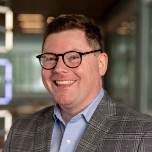

Professor Terence Johnson

Some of this course builds on DS 3001 materials he created for earlier offerings.

## Before Monday

1. Sign in to Canvas and read the syllabus.
2. Make sure you can sign in to your GitHub account.
3. Open the course website and the get-started materials.
4. If Python, Jupyter, Git, or GitHub is new to you, work through those materials.

## SDAC Volunteer Notetaker Needed

The Student Disability Access Center is looking for a **volunteer notetaker** for this class.

- Keep taking the notes you already take for yourself; no additional notes are required.
- Notes do not need to be perfect. They should be legible and capture the main ideas from each class.
- Upload a copy of your notes to the SDAC Portal each week.
- Use this volunteer role as a resume-builder, volunteer hours, or community service for a club or other organization.

[Complete the Notetaker Application](https://yukon.accessiblelearning.com/Virginia/Notetaker.aspx)

Questions? Call SDAC at 434-243-5180 or email notes@virginia.edu.